# Data Mining / Unsupervised Learning

### Aprendizado não supervisionado

- Também conhecido como mineração de dados, que um sub-campo do Aprendizado de Máquina que foca mais em análise exploratória de dados.
- O aprendizado não supervisionado pode ser um objetivo em si mesmo (descobrir novos padrões nos dados) ou um meio para atingir um fim.

#### *Clustering*

- Técnica para fazer agrupamentos automáticos de dados segundo seu grau de semelhança.
- O critério de semelhança faz parte da definição do problema.
- Tipos mais comuns:
  - Particionais
  - Hierárquicos

##### *Hierarquical Clustering*

No agrupamento hierárquico, os dois *clusters* mais semelhantes são combinados e continuam a combinar até que todos os objetos estejam no mesmo *cluster*.

O agrupamento hierárquico produz uma árvore (chamada de dendograma) que mostra a hierarquia dos *clusters*.

Opta-se por escolher os *clusters* por quantidade de clusters ou por similaridade mínima.

Na **Agglomerative** (abordagem “de baixo para cima”) cada observação começa em seu próprio *cluster*, e pares de *clusters* são mesclados à medida que se sobe na hierarquia.

**Distância**: Métrica para determinar a similaridade entre dois clusters / observações, com um valor entre 0 e 1. * Euclidiana (raiz do somatório dos quadrados das diferenças)

**Linkage**: Distância entre *‘subclusters’*. * Máxima, Mínima, Média, etc

##### Exemplo

**Dados das TED talks**

```r
library(tidyverse)
library(jsonlite)
Sys.setlocale( locale = "pt_BR")
```

```
## [1] "pt_BR/pt_BR/pt_BR/C/pt_BR/C"
```

```r
ted_data <- read_csv("data/ted_main.csv")
```

Vamos utilizar alguns dados ainda não explorados, as tags. Primeiro, será necessário extrair as tags da lista para uma variável

```r
ted_data %>%
  select( url, tags ) %>%
  mutate( url = str_replace( url, '\n', '' )  # Retira o Enter do final da URL
        , all_tags = tags %>%
            str_replace_all( "\\[", '' ) %>%  # Colchetes
            str_replace_all( "\\]", '' ) %>%  # Colchetes
            str_replace_all( "'", "" ) %>%    # Delimitador de cada tag (aspas)
            str_split( pattern = ', ' ) ) %>% # Delimitador entre tags (vírgula seguida de espaço)
  unnest( all_tags ) %>%                      # Extrai a lista de tags para um novo campo
  mutate( tag = factor( all_tags )) %>%       # Converte para tipo Factor
  select( -tags, -all_tags ) -> ted_tags
# Vamos ver a contagem de tags
ted_tags %>%
  count( tag ) %>%
  arrange( desc( n ))
```

| tag | n |
| --- | --- |
| technology | 727 |
| science | 567 |
| global issues | 501 |
| culture | 486 |
| TEDx | 450 |
| design | 418 |
| business | 348 |
| entertainment | 299 |
| health | 236 |
| innovation | 229 |

[output cut: 406 more lines]

```r
# E as estatísticas descritivas de quantidade de tags por vídeo

ted_tags %>%
  count( url ) %>%
  select( -url ) %>%
  pull( n ) %>%
  summary()
```

```
##    Min. 1st Qu.  Median    Mean 3rd Qu.    Max.
##   1.000   5.000   6.000   7.511   9.000  32.000
```

Identificamos que muitas tags foram utilizadas em diferentes vídeos. O que podemos aprender sobre os vídeos utilizando as tags?

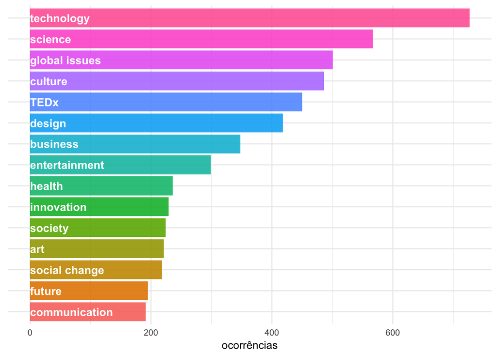

```r
ted_tags %>%
  count( tag ) %>%
  top_n( 15 ) %>%
  mutate( tag = reorder(tag, n )) %>%
  ggplot( aes( tag, n, label = tag, fill = tag )) +
  geom_col( alpha = 0.9, show.legend = FALSE ) +
  geom_text( aes( tag, 0.001 ), hjust = 0, color = "white", size = 4, fontface = "bold" ) +
  coord_flip() +
  labs( x = NULL, y = "ocorrências" ) +
  theme_minimal() +
  theme( axis.text.y=element_blank() )
```

Clustering em R requer o uso de matrizes. Precisamos transformar a ocorrência de cada tag em uma coluna.

Matrizes são de tipagem homogênea. As strings (tag, url) devem ser transformadas em nomes de colunas (tags) e linhas (urls).

Aplicaremos uma transformação em escalas para centralizar as medidas e converter todas contagens em uma mesma escala.

```r
sparse_tag_matrix <- ted_tags %>%
  mutate( val = 1L ) %>%
  spread( key = tag, value = val, fill = 0L ) %>%
  column_to_rownames( "url" ) %>%
  as.matrix()
tags_scaled <- scale( sparse_tag_matrix )
```

##### **Clustering** com as tags

Uma forma de determinar a similaridade entre os vídeos é utilizando a correlação entre eles. Vídeos com tags em comum terão correlação mais alta (tendendo a 1), e precisamos representar aqueles mais similares com valores tendendo a zero.

```r
dissimilarity <- 1 - cor( t(tags_scaled), method = "pearson" )
distance <- as.dist( dissimilarity ) # Função que transforma matriz de similaridade em matriz de distâncias
```

Função para clusterização hierárquica

```r
hc <- hclust( distance )
```

Neste exemplo definiremos os clusters como grupos com correlação de pelo menos 0.6 (distância de até 0.4)

```r
agglom <- cutree(hc, h=0.40)

ted_data %>%
  add_column( cluster = agglom ) -> ted_data
```

Quais clusters criamos? Quantos vídeos por cluster?

```r
(clusters <- agglom %>% table() %>% sort(decreasing = TRUE))
```

```
## .
##    6  144  189  281  360  683  798    7  141  302  317  412  464  473  527
##   15    8    8    8    8    8    8    7    7    7    7    7    7    7    7
##  623  490  520  547  731  931  976   55   67   95   97  135  169  205  219
##    7    6    6    6    6    6    6    5    5    5    5    5    5    5    5
##  273  291  315  340  366  388  400  442  566  572  626  637  676  719  775
##    5    5    5    5    5    5    5    5    5    5    5    5    5    5    5
##  859  975 1020   51   82   88   93  116  121  131  138  163  164  170  172
##    5    5    5    4    4    4    4    4    4    4    4    4    4    4    4
##  197  211  217  226  243  275  296  301  306  326  330  364  371  384  402
##    4    4    4    4    4    4    4    4    4    4    4    4    4    4    4
##  407  415  416  421  426  438  446  531  559  564  573  640  648  654  659
##    4    4    4    4    4    4    4    4    4    4    4    4    4    4    4
##  675  723  789  989 1028 1030 1042 1206    2    5   19   24   43   45   50
##    4    4    4    4    4    4    4    4    3    3    3    3    3    3    3
```

[output cut: 198 more lines]

```r
clusters_por_contagem <- clusters %>% names()

ted_data %>%
  filter( cluster == clusters_por_contagem[1] )
```

| comments | description | duration | event | film_date | languages | main_speaker | name | num_speaker | published_date | ratings | related_talks | speaker_occupation | tags | title | url | views | cluster |
| --- | --- | --- | --- | --- | --- | --- | --- | --- | --- | --- | --- | --- | --- | --- | --- | --- | --- |
| 672 | Tony Robbins discusses the "invisible forces" that motivate everyone's actions -- and high-fives Al Gore in the front row. | 1305 | TED2006 | 1138838400 | 36 | Tony Robbins | Tony Robbins: Why we do what we do | 1 | 1151440680 | [{'id': 7, 'name': 'Funny', 'count': 1102}, {'id': 3, 'name': 'Courageous', 'count': 721}, {'id': 21, 'name': 'Unconvincing', 'count': 377}, {'id': 2, 'name': 'Confusing', 'count': 301}, {'id': 1, 'na… | [{'id': 229, 'hero': 'https://pe.tedcdn.com/images/ted/eefe30d20338d800bdc70a09dc0f6007e7355a74_2880x1620.jpg', 'speaker': 'Jill Bolte Taylor', 'title': 'My stroke of insight', 'duration': 1099, 'slug… | Life coach; expert in leadership psychology | ['business', 'culture', 'entertainment', 'goal-setting', 'motivation', 'potential', 'psychology'] | Why we do what we do | https://www.ted.com/talks/tony_robbins_asks_why_we_do_what_we_do\n | 20685401 | 6 |
| 67 | Ashraf Ghani's passionate and powerful 10-minute talk, emphasizing the necessity of both economic investment and design ingenuity to rebuild broken states, is followed by a conversation with TED curat… | 1125 | TEDGlobal 2005 | 1121126400 | 24 | Ashraf Ghani | Ashraf Ghani: How to rebuild a broken state | 1 | 1161130260 | [{'id': 3, 'name': 'Courageous', 'count': 139}, {'id': 2, 'name': 'Confusing', 'count': 25}, {'id': 1, 'name': 'Beautiful', 'count': 48}, {'id': 9, 'name': 'Ingenious', 'count': 31}, {'id': 21, 'name'… | [{'id': 127, 'hero': 'https://pe.tedcdn.com/images/ted/5cd871dcf27ba4288021c2bfe6a3f6796dab2538_2880x1620.jpg', 'speaker': 'Ngozi Okonjo-Iweala', 'title': 'Want to help Africa? Do business here', 'dur… | President-elect of Afghanistan | ['business', 'corruption', 'culture', 'economics', 'entrepreneur', 'global development', 'global issues', 'investment', 'military', 'policy', 'politics', 'poverty'] | How to rebuild a broken state | https://www.ted.com/talks/ashraf_ghani_on_rebuilding_broken_states\n | 809226 | 6 |
| 151 | Is the beloved paper dictionary doomed to extinction? In this infectiously exuberant talk, leading lexicographer Erin McKean looks at the many ways today's print dictionary is poised for transformatio… | 950 | TED2007 | 1172880000 | 32 | Erin McKean | Erin McKean: The joy of lexicography | 1 | 1188459000 | [{'id': 3, 'name': 'Courageous', 'count': 45}, {'id': 10, 'name': 'Inspiring', 'count': 343}, {'id': 22, 'name': 'Fascinating', 'count': 518}, {'id': 1, 'name': 'Beautiful', 'count': 195}, {'id': 7, '… | [{'id': 69, 'hero': 'https://pe.tedcdn.com/images/ted/8bdfb6113efedf37e72cd88aa1dcf8103bcbf4e0_800x600.jpg', 'speaker': 'Wade Davis', 'title': 'Dreams from endangered cultures', 'duration': 1321, 'slu… | Dictionary editor | ['books', 'culture', 'education', 'entertainment', 'language'] | The joy of lexicography | https://www.ted.com/talks/erin_mckean_redefines_the_dictionary\n | 1013063 | 6 |
| 143 | In this image-filled talk, Yann Arthus-Bertrand displays his three most recent projects on humanity and our habitat -- stunning aerial photographs in his series "The Earth From Above," personal interv… | 894 | TED2009 | 1233705600 | 31 | Yann Arthus-Bertrand | Yann Arthus-Bertrand: A wide-angle view of fragile Earth | 1 | 1243990800 | [{'id': 11, 'name': 'Longwinded', 'count': 29}, {'id': 21, 'name': 'Unconvincing', 'count': 44}, {'id': 26, 'name': 'Obnoxious', 'count': 14}, {'id': 2, 'name': 'Confusing', 'count': 16}, {'id': 24, '… | [{'id': 324, 'hero': 'https://pe.tedcdn.com/images/ted/70b5e4c2b22d64d8ddce53144d55d10fb4c08909_1600x1200.jpg', 'speaker': 'David Griffin', 'title': 'How photography connects us', 'duration': 893, 'sl… | Photographer | ['art', 'climate change', 'environment', 'film', 'future', 'humanity', 'media', 'photography'] | A wide-angle view of fragile Earth | https://www.ted.com/talks/yann_arthus_bertrand_captures_fragile_earth_in_wide_angle\n | 751889 | 6 |
| 718 | What do you think of people in poverty? Maybe what Jessica Jackley once did: "they" need "our" help, in the form of a few coins in a jar. The co-founder of Kiva.org talks about how her attitude change… | 1113 | TEDGlobal 2010 | 1279065600 | 35 | Jessica Jackley | Jessica Jackley: Poverty, money -- and love | 1 | 1287394020 | [{'id': 10, 'name': 'Inspiring', 'count': 1535}, {'id': 24, 'name': 'Persuasive', 'count': 374}, {'id': 8, 'name': 'Informative', 'count': 206}, {'id': 3, 'name': 'Courageous', 'count': 420}, {'id': 1… | [{'id': 79, 'hero': 'https://pe.tedcdn.com/images/ted/152_480x360.jpg', 'speaker': 'Iqbal Quadir', 'title': 'How mobile phones can fight poverty', 'duration': 952, 'slug': 'iqbal_quadir_says_mobiles_f… | Microlender | ['business', 'entrepreneur', 'global issues', 'poverty', 'social change', 'women in business'] | Poverty, money -- and love | https://www.ted.com/talks/jessica_jackley_poverty_money_and_love\n | 1359611 | 6 |
| 115 | At the onstage introduction of Twirlr, a new social-sharing platform, someone forgets to silence their cell phone. And then ... this happens. (Song by Scott Brown and Anthony King; edit by Nathan Russ… | 200 | Gel Conference | 1303948800 | 0 | Improv Everywhere | Improv Everywhere: Gotta share! | 1 | 1306083600 | [{'id': 7, 'name': 'Funny', 'count': 735}, {'id': 22, 'name': 'Fascinating', 'count': 58}, {'id': 24, 'name': 'Persuasive', 'count': 25}, {'id': 26, 'name': 'Obnoxious', 'count': 218}, {'id': 9, 'name… | [{'id': 473, 'hero': 'https://pe.tedcdn.com/images/ted/74570_800x600.jpg', 'speaker': 'Evan Williams', 'title': 'The voices of Twitter users', 'duration': 480, 'slug': 'evan_williams_on_listening_to_t… | Pranksters | ['entertainment', 'social media'] | Gotta share! | https://www.ted.com/talks/gel_gotta_share\n | 357454 | 6 |
| 100 | In the 1970s, Diana Nyad set long-distance swim records that are still unbroken. Thirty years later, at 60, she attempted her longest swim yet, from Cuba to Florida. In this funny, powerful talk at TE… | 1017 | TEDMED 2011 | 1319760000 | 26 | Diana Nyad | Diana Nyad: Extreme swimming with the world's most dangerous jellyfish | 1 | 1327422189 | [{'id': 23, 'name': 'Jaw-dropping', 'count': 112}, {'id': 10, 'name': 'Inspiring', 'count': 479}, {'id': 24, 'name': 'Persuasive', 'count': 52}, {'id': 1, 'name': 'Beautiful', 'count': 74}, {'id': 3, … | [{'id': 928, 'hero': 'https://pe.tedcdn.com/images/ted/187709_800x600.jpg', 'speaker': 'Lewis Pugh', 'title': 'My mind-shifting Everest swim', 'duration': 585, 'slug': 'lewis_pugh_s_mind_shifting_mt_e… | Journalist, swimmer | ['culture', 'extreme sports', 'fear', 'sports', 'success'] | Extreme swimming with the world's most dangerous jellyfish | https://www.ted.com/talks/diana_nyad_extreme_swimming_with_the_world_s_most_dangerous_jellyfish\n | 611461 | 6 |
| 63 | The New Yorker receives around 1,000 cartoons each week; it only publishes about 17 of them. In this hilarious, fast-paced, and insightful talk, the magazine's longstanding cartoon editor and self-pro… | 1259 | TEDSalon NY2013 | 1368662400 | 25 | Bob Mankoff | Bob Mankoff: Anatomy of a New Yorker cartoon | 1 | 1372258804 | [{'id': 7, 'name': 'Funny', 'count': 616}, {'id': 8, 'name': 'Informative', 'count': 217}, {'id': 22, 'name': 'Fascinating', 'count': 123}, {'id': 25, 'name': 'OK', 'count': 43}, {'id': 9, 'name': 'In… | [{'id': 524, 'hero': 'https://pe.tedcdn.com/images/ted/85390_800x600.jpg', 'speaker': 'Ben Katchor', 'title': 'Comics of bygone New York', 'duration': 671, 'slug': 'ben_katchor_s_comics_of_old_new_yor… | Cartoon editor | ['art', 'comedy', 'design', 'humor'] | Anatomy of a New Yorker cartoon | https://www.ted.com/talks/bob_mankoff_anatomy_of_a_new_yorker_cartoon\n | 1168185 | 6 |
| 186 | In Lebanon there is one gunshot a year that isn’t part of a scene of routine violence: The opening sound of the Beirut International Marathon. In a moving talk, marathon founder May El-Khalil explains… | 616 | TEDGlobal 2013 | 1371859200 | 40 | May El-Khalil | May El-Khalil: Making peace is a marathon | 1 | 1376665207 | [{'id': 10, 'name': 'Inspiring', 'count': 358}, {'id': 9, 'name': 'Ingenious', 'count': 23}, {'id': 1, 'name': 'Beautiful', 'count': 111}, {'id': 3, 'name': 'Courageous', 'count': 195}, {'id': 24, 'na… | [{'id': 55, 'hero': 'https://pe.tedcdn.com/images/ted/216_480x360.jpg', 'speaker': 'Jehane Noujaim', 'title': 'My wish: A global day of film', 'duration': 1538, 'slug': 'jehane_noujaim_inspires_a_glob… | Founder of the Beirut Marathon | ['culture', 'global issues', 'sports', 'violence', 'war'] | Making peace is a marathon | https://www.ted.com/talks/may_el_khalil_making_peace_is_a_marathon\n | 5182832 | 6 |
| 293 | "We spend so much time listening to the things people are saying that we rarely pay attention to the things they don't," says poet and teacher Clint Smith. A short, powerful piece from the heart, abou… | 258 | TED@NYC | 1404777600 | 40 | Clint Smith | Clint Smith: The danger of silence | 1 | 1408117565 | [{'id': 1, 'name': 'Beautiful', 'count': 1544}, {'id': 3, 'name': 'Courageous', 'count': 1355}, {'id': 10, 'name': 'Inspiring', 'count': 3182}, {'id': 22, 'name': 'Fascinating', 'count': 367}, {'id': … | [{'id': 1625, 'hero': 'https://pe.tedcdn.com/images/ted/77f51be04c3531bb9b22eb93029eb01a3d991ff1_1600x1200.jpg', 'speaker': 'Lemon Andersen', 'title': "Please don't take my Air Jordans", 'duration': 5… | Poet, educator | ['poetry', 'social change', 'spoken word'] | The danger of silence | https://www.ted.com/talks/clint_smith_the_danger_of_silence\n | 3804535 | 6 |

[output cut: 5 more lines]

```r
ted_data %>%
  filter( cluster == clusters_por_contagem[2] )
```

| comments | description | duration | event | film_date | languages | main_speaker | name | num_speaker | published_date | ratings | related_talks | speaker_occupation | tags | title | url | views | cluster |
| --- | --- | --- | --- | --- | --- | --- | --- | --- | --- | --- | --- | --- | --- | --- | --- | --- | --- |
| 101 | Kenichi Ebina moves his body in a manner that appears to defy the limits imposed by the human skeleton. He combines breakdancing and hip-hop with mime using movements that are simultaneously precise a… | 212 | TED2007 | 1172880000 | 43 | Kenichi Ebina | Kenichi Ebina: My magic moves | 1 | 1191403500 | [{'id': 7, 'name': 'Funny', 'count': 307}, {'id': 1, 'name': 'Beautiful', 'count': 414}, {'id': 21, 'name': 'Unconvincing', 'count': 200}, {'id': 22, 'name': 'Fascinating', 'count': 562}, {'id': 9, 'n… | [{'id': 24, 'hero': 'https://pe.tedcdn.com/images/ted/22_480x360.jpg', 'speaker': 'Pilobolus', 'title': 'A dance of "Symbiosis"', 'duration': 825, 'slug': 'pilobolus_perform_symbiosis', 'viewed_count'… | Dancer | ['culture', 'dance', 'entertainment', 'performance'] | My magic moves | https://www.ted.com/talks/kenichi_ebina_s_magic_moves\n | 1720579 | 144 |
| 552 | Sunitha Krishnan has dedicated her life to rescuing women and children from sex slavery, a multimilion-dollar global market. In this courageous talk, she tells three powerful stories, as well as her o… | 762 | TEDIndia 2009 | 1257379200 | 33 | Sunitha Krishnan | Sunitha Krishnan: The fight against sex slavery | 1 | 1260147600 | [{'id': 10, 'name': 'Inspiring', 'count': 1327}, {'id': 8, 'name': 'Informative', 'count': 407}, {'id': 3, 'name': 'Courageous', 'count': 1880}, {'id': 23, 'name': 'Jaw-dropping', 'count': 590}, {'id'… | [{'id': 494, 'hero': 'https://pe.tedcdn.com/images/ted/79736_800x600.jpg', 'speaker': 'Jacqueline Novogratz', 'title': 'An escape from poverty', 'duration': 450, 'slug': 'jacqueline_novogratz_on_an_es… | Anti-trafficking crusader | ['Asia', 'Slavery', 'children', 'global issues', 'poverty', 'sex', 'sexual violence', 'trafficking', 'women'] | The fight against sex slavery | https://www.ted.com/talks/sunitha_krishnan_tedindia\n | 2543750 | 144 |
| 117 | Photographs do more than document history -- they make it. At TED University, Jonathan Klein of Getty Images shows some of the most iconic, and talks about what happens when a generation sees an image… | 362 | TED2010 | 1265846400 | 36 | Jonathan Klein | Jonathan Klein: Photos that changed the world | 1 | 1271151120 | [{'id': 21, 'name': 'Unconvincing', 'count': 71}, {'id': 1, 'name': 'Beautiful', 'count': 184}, {'id': 25, 'name': 'OK', 'count': 158}, {'id': 10, 'name': 'Inspiring', 'count': 527}, {'id': 24, 'name'… | [{'id': 324, 'hero': 'https://pe.tedcdn.com/images/ted/70b5e4c2b22d64d8ddce53144d55d10fb4c08909_1600x1200.jpg', 'speaker': 'David Griffin', 'title': 'How photography connects us', 'duration': 893, 'sl… | Executive | ['global issues', 'media', 'photography', 'poverty', 'war'] | Photos that changed the world | https://www.ted.com/talks/jonathan_klein_photos_that_changed_the_world\n | 1209663 | 144 |
| 373 | In this rare clip from 1972, legendary psychiatrist and Holocaust-survivor Viktor Frankl delivers a powerful message about the human search for meaning -- and the most important gift we can give other… | 262 | Toronto Youth Corps | 74649600 | 0 | Viktor Frankl | Viktor Frankl: Why believe in others | 1 | 1273847820 | [{'id': 10, 'name': 'Inspiring', 'count': 1673}, {'id': 1, 'name': 'Beautiful', 'count': 346}, {'id': 24, 'name': 'Persuasive', 'count': 455}, {'id': 23, 'name': 'Jaw-dropping', 'count': 124}, {'id': … | [{'id': 272, 'hero': 'https://pe.tedcdn.com/images/ted/120ccfcc17a4370989d4dffdea7c040842854036_1600x1200.jpg', 'speaker': 'Philip Zimbardo', 'title': 'The psychology of evil', 'duration': 1396, 'slug… | Psychiatrist, neurologist, author | ['humanity', 'mind', 'peace', 'psychology', 'war'] | Why believe in others | https://www.ted.com/talks/viktor_frankl_youth_in_search_of_meaning\n | 1028630 | 144 |
| 285 | Hailed as the greatest pickpocket in the world, Apollo Robbins studies the quirks of human behavior as he steals your watch. In a hilarious demonstration, Robbins samples the buffet of the TEDGlobal 2… | 527 | TEDGlobal 2013 | 1370995200 | 37 | Apollo Robbins | Apollo Robbins: The art of misdirection | 1 | 1379084559 | [{'id': 24, 'name': 'Persuasive', 'count': 418}, {'id': 23, 'name': 'Jaw-dropping', 'count': 1873}, {'id': 7, 'name': 'Funny', 'count': 1864}, {'id': 9, 'name': 'Ingenious', 'count': 714}, {'id': 1, '… | [{'id': 1496, 'hero': 'https://pe.tedcdn.com/images/ted/a7995733cb7730a7f26ddaca08aee95ac23b4999_1600x1200.jpg', 'speaker': 'Marc Goodman', 'title': 'A vision of crimes in the future', 'duration': 116… | Gentleman thief | ['crime', 'entertainment'] | The art of misdirection | https://www.ted.com/talks/apollo_robbins_the_art_of_misdirection\n | 15283242 | 144 |
| 106 | McKenna Pope's younger brother loved to cook, but he worried about using an Easy-Bake Oven -- because it was a toy for girls. So at age 13, Pope started an online petition for the American toy company… | 322 | TEDYouth 2013 | 1385164800 | 38 | McKenna Pope | McKenna Pope: Want to be an activist? Start with your toys | 1 | 1391011387 | [{'id': 10, 'name': 'Inspiring', 'count': 283}, {'id': 8, 'name': 'Informative', 'count': 35}, {'id': 9, 'name': 'Ingenious', 'count': 26}, {'id': 26, 'name': 'Obnoxious', 'count': 66}, {'id': 22, 'na… | [{'id': 1279, 'hero': 'https://pe.tedcdn.com/images/ted/2c27ecb6e44a7197c2e1ffee6647ec9add7e93c6_800x600.jpg', 'speaker': 'Natalie Warne', 'title': 'Being young and making an impact', 'duration': 769,… | Teen activist | ['TEDYouth', 'activism', 'toy', 'youth'] | Want to be an activist? Start with your toys | https://www.ted.com/talks/mckenna_pope_want_to_be_an_activist_start_with_your_toys\n | 917406 | 144 |
| 101 | Sting’s early life was dominated by a shipyard—and he dreamed of nothing more than escaping the industrial drudgery. But after a nasty bout of writer’s block that stretched on for years, Sting found h… | 1395 | TED2014 | 1395100800 | 25 | Sting | Sting: How I started writing songs again | 1 | 1401461164 | [{'id': 1, 'name': 'Beautiful', 'count': 688}, {'id': 3, 'name': 'Courageous', 'count': 145}, {'id': 10, 'name': 'Inspiring', 'count': 867}, {'id': 22, 'name': 'Fascinating', 'count': 262}, {'id': 8, … | [{'id': 1983, 'hero': 'https://pe.tedcdn.com/images/ted/aa39c73bae9d19372ed2059e7c8b0b7eb9099865_1600x1200.jpg', 'speaker': 'Elizabeth Gilbert', 'title': 'Success, failure and the drive to keep creati… | Composer, singer, author, actor, activist | ['creativity', 'live music', 'music', 'performance'] | How I started writing songs again | https://www.ted.com/talks/sting_how_i_started_writing_songs_again\n | 1934877 | 144 |
| 65 | Self-driving cars were just the start. What's the future of big data-driven technology and design? In a thrilling science talk, Kenneth Cukier looks at what's next for machine learning -- and human kn… | 951 | TEDSalon Berlin 2014 | 1403481600 | 23 | Kenneth Cukier | Kenneth Cukier: Big data is better data | 1 | 1411486918 | [{'id': 8, 'name': 'Informative', 'count': 620}, {'id': 10, 'name': 'Inspiring', 'count': 203}, {'id': 22, 'name': 'Fascinating', 'count': 234}, {'id': 24, 'name': 'Persuasive', 'count': 126}, {'id': … | [{'id': 937, 'hero': 'https://pe.tedcdn.com/images/ted/192641_800x600.jpg', 'speaker': 'David McCandless', 'title': 'The beauty of data visualization', 'duration': 1076, 'slug': 'david_mccandless_the_… | Data Editor of The Economist | ['data', 'future', 'technology'] | Big data is better data | https://www.ted.com/talks/kenneth_cukier_big_data_is_better_data\n | 1305783 | 144 |

**Interpretações? Tentem listar os vídeos de outros clusters para entender os temas.**

Agora vamos estudar uma técnica que nos ajudará a formar *clusters* mais coesos.

#### Principal Component Analysis (Análise de Componentes Principais)

- Procedimento matemático que aplica transformações ortogonais para converter observações de variáveis possivelmente correlacionadas em conjunto de variáveis linearmente não correlacionadas (componentes principais)
- O primeiro componente principal tem a maior variância possível
  - é responsável pelo máximo de variabilidade nos dados
- Cada componente seguinte tem a máxima variância sob a restrição de não ser correlacionado com os componentes anteriores
- O número de componentes principais é menor ou igual ao número de variáveis originais

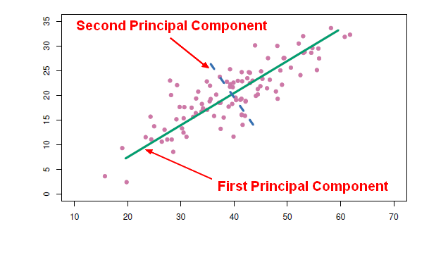

Tal como nas técnicas de agrupamento, a escolha do número de componentes principais é de atribuição do analista.

```r
### INSTALAR ESTA PACKAGE ###
#install.packages("irlba")   # Package de melhor desempenho para tarefas de componentes principais

tags_pca <- irlba::prcomp_irlba(tags_scaled, n = 16)
```

##### Importância (cumulativa) dos componentes

```r
percent_variation <- tags_pca$sdev^2 / sum(tags_pca$sdev^2)

scales::percent( cumsum( percent_variation ))
```

```
##  [1] "11.4%"  "20.7%"  "29.5%"  "37.6%"  "44.7%"  "51.3%"  "57.2%"
##  [8] "62.9%"  "68.1%"  "73.0%"  "78.0%"  "82.6%"  "87.1%"  "91.5%"
## [15] "95.8%"  "100.0%"
```

##### Importância das variáveis

```r
### INSTALAR ESTA PACKAGE ###
# install.packages("FactoMineR")
# install.packages("factoextra")

library(FactoMineR)
library(factoextra)
```

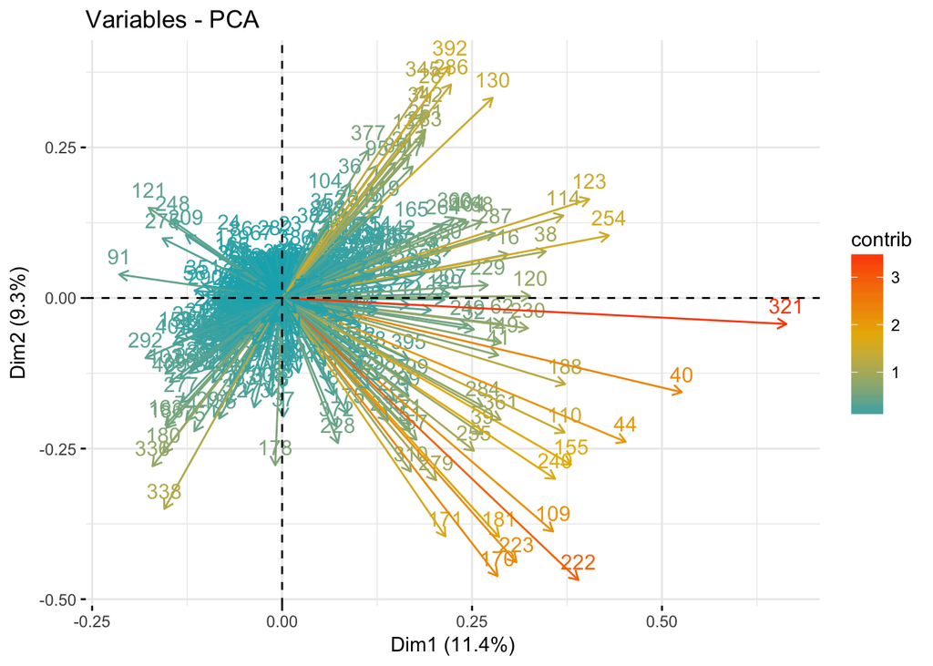

```r
fviz_pca_var( tags_pca, col.var="contrib"
            , gradient.cols = c("#00AFBB", "#E7B800", "#FC4E07" ))
```

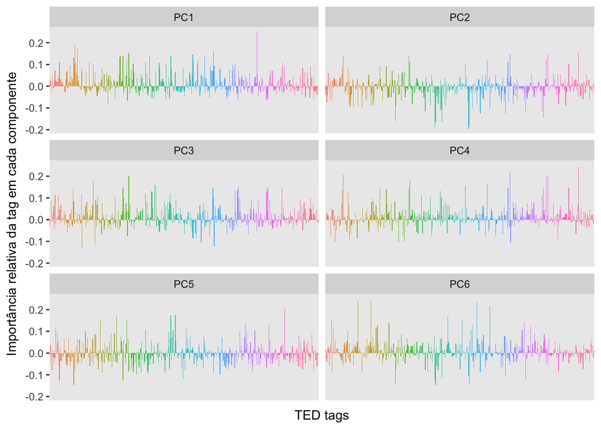

```r
library(broom)

tidied_pca <-
  bind_cols( tag = colnames(tags_scaled)
           , tidy( tags_pca$rotation )) %>%
  gather( PC, Contribution, PC1:PC16 )

tidied_pca %>%
  filter(PC %in% paste0("PC", 1:6)) %>%
  ggplot(aes(tag, Contribution, fill = tag)) +
  geom_col(show.legend = FALSE, alpha = 0.8) +
  theme(axis.text.x = element_blank(),
        axis.ticks.x = element_blank(),
        panel.grid.major = element_blank(),
        panel.grid.minor = element_blank()) +
  labs(x = "TED tags",
       y = "Importância relativa da tag em cada componente") +
  facet_wrap(~ PC, ncol = 2)
```

##### Importância das variáveis em cada componente

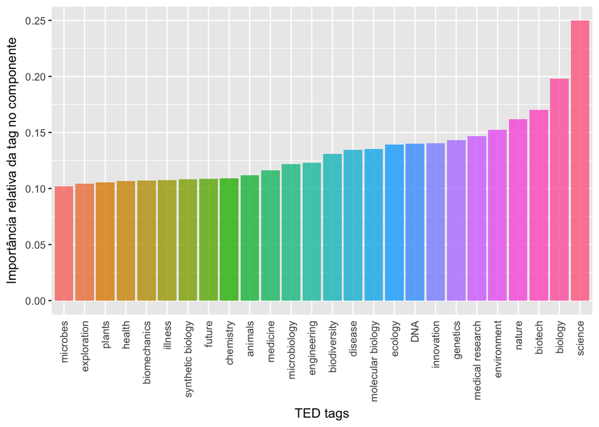

```r
tidied_pca %>%
  filter(PC == "PC1") %>%
  top_n(40, abs(Contribution)) %>%
  filter( abs( Contribution ) >= 0.1 ) %>%
  mutate(tag = reorder(tag, Contribution)) %>%
  ggplot(aes(tag, Contribution, fill = tag)) +
  geom_col(show.legend = FALSE, alpha = 0.8) +
  theme(axis.text.x = element_text(angle = 90, hjust = 1, vjust = 0.5),
        axis.ticks.x = element_blank()) +
  labs(x = "TED tags",
       y = "Importância relativa da tag no componente")
```

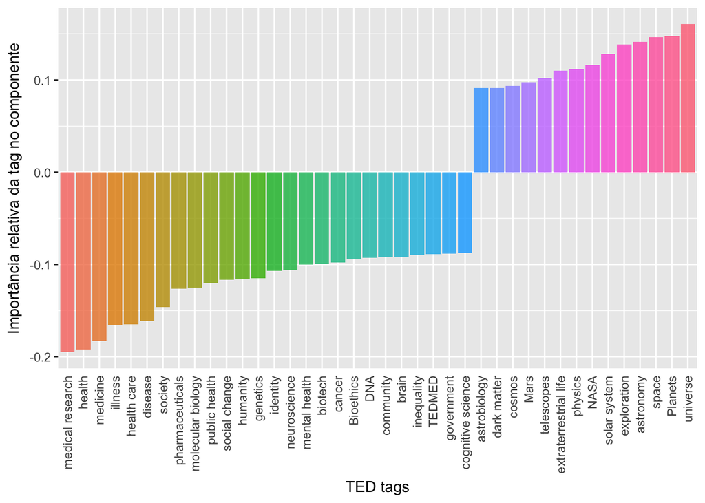

```r
tidied_pca %>%
  filter(PC == "PC2") %>%
  top_n(40, abs(Contribution)) %>%
  mutate(tag = reorder(tag, Contribution)) %>%
  ggplot(aes(tag, Contribution, fill = tag)) +
  geom_col(show.legend = FALSE, alpha = 0.8) +
  theme(axis.text.x = element_text(angle = 90, hjust = 1, vjust = 0.5),
        axis.ticks.x = element_blank()) +
  labs(x = "TED tags",
       y = "Importância relativa da tag no componente")
```

##### Ortogonalidade dos componentes (2o e 3o)

```r
augmented_pca <- bind_cols(ted_talk = rownames(tags_scaled), tidy(tags_pca$x))

augmented_pca
```

| ted_talk | PC1 | PC2 | PC3 | PC4 | PC5 | PC6 | PC7 | PC8 | PC9 | PC10 | PC11 | PC12 | PC13 | PC14 | PC15 | PC16 |
| --- | --- | --- | --- | --- | --- | --- | --- | --- | --- | --- | --- | --- | --- | --- | --- | --- |
| https://www.ted.com/talks/9_11_healing_the_mothers_who_found_forgiveness_friendship | -1.8391763949 | -0.527881123 | 0.0714308541 | 0.1393023457 | -1.456983e+00 | -1.748714e-01 | 1.018116e-01 | -0.081757913 | 1.153403e+00 | -6.446151e-02 | 7.096017e-01 | 1.903224e+00 | 2.016528e-01 | -9.066278e-01 | -6.411014e-01 | -4.839110e-01 |
| https://www.ted.com/talks/a_choir_as_big_as_the_internet | -1.7964075152 | 1.077023327 | -1.0857558948 | -1.0025979926 | 1.361828e+00 | -6.606858e-01 | -1.385986e-01 | 2.266702427 | -2.489313e+00 | -2.783350e-01 | -1.320394e+00 | 7.597578e-01 | -6.896689e-01 | 5.701815e-01 | -4.809701e-01 | 4.017421e-01 |
| https://www.ted.com/talks/a_j_jacobs_year_of_living_biblically | -2.0875074876 | 0.389985768 | -1.2469687664 | -0.5825783786 | -1.494899e+00 | 1.511964e-01 | -1.069746e+00 | 0.780173423 | 3.290411e-01 | 5.202051e-01 | 8.537304e-01 | 1.837939e+00 | 2.914557e+00 | 9.418254e-01 | -1.231428e+00 | -3.581191e-01 |
| https://www.ted.com/talks/a_robot_that_flies_like_a_bird | 1.9197105155 | 0.790432134 | -0.7229465516 | -1.5987637161 | 1.286669e+00 | 9.509481e-01 | -2.867991e-01 | 1.584846790 | 1.572138e+00 | -4.035489e-01 | -7.518840e-01 | -8.625160e-01 | 3.738560e-01 | -2.374224e+00 | -3.754638e-01 | 6.976191e-01 |
| https://www.ted.com/talks/a_ted_speaker_s_worst_nightmare | -1.6103636250 | 1.056583253 | -1.2957950242 | -1.3516078038 | -3.460355e-01 | -9.303241e-01 | -1.058445e+00 | 1.202680305 | -2.230122e+00 | 7.389019e-01 | -2.229199e-01 | -1.799062e-02 | -9.122519e-02 | 2.572590e-01 | -4.906086e-02 | 6.802832e-02 |
| https://www.ted.com/talks/a_whistleblower_you_haven_t_heard | -1.8297642226 | 1.450442507 | -1.9803287342 | -1.9989412114 | -2.035085e-01 | -1.548784e+00 | -1.109364e+00 | 1.718822791 | -4.810241e+00 | 1.538832e+00 | -5.307596e-01 | -4.840807e-02 | -4.051823e-01 | 7.784113e-02 | -1.245992e+00 | -1.248579e-01 |
| https://www.ted.com/talks/aakash_odedra_a_dance_in_a_hurricane_of_paper_wind_and_light | -1.5619898472 | 1.182797732 | -1.6102041693 | -1.5566235229 | -1.519128e-01 | -1.173650e+00 | -8.579392e-01 | 1.030147887 | -3.057132e+00 | 8.333595e-01 | -3.423212e-01 | 7.138341e-02 | -8.748272e-02 | -3.940129e-02 | -4.749232e-01 | -3.203219e-02 |
| https://www.ted.com/talks/aala_el_khani_what_it_s_like_to_be_a_parent_in_a_war_zone | -4.9252430049 | -6.295584309 | 5.8439020860 | 5.9877482126 | -4.465809e+00 | 1.965128e+00 | 1.573794e+00 | 5.128505198 | 1.611177e+00 | 7.456657e+00 | 5.481267e+00 | 3.838941e+00 | -4.423455e+00 | -1.069605e+01 | 3.998855e+00 | -2.397644e+00 |
| https://www.ted.com/talks/aaron_huey | -1.2084887254 | 0.650171122 | -0.3157202946 | -0.7881669644 | -5.088685e-01 | -7.236416e-01 | 6.442970e-01 | -0.106792406 | 8.353529e-01 | -7.705111e-01 | 5.985672e-02 | -1.932714e-01 | 5.898152e-02 | 2.248883e-01 | 2.401292e-01 | -3.773742e-02 |
| https://www.ted.com/talks/aaron_koblin | 0.2317632809 | 1.035556987 | -0.4211018641 | 0.2579003653 | 2.614964e+00 | -2.090776e-01 | -1.260465e+00 | 2.324188696 | 1.186721e+00 | -1.289696e+00 | 9.516047e-01 | 8.996693e-01 | 3.108770e-02 | 1.442664e+00 | 5.183139e-01 | 9.582910e-01 |

[output cut: 2540 more lines]

```r
library(scales)
```

[figure not shown]

```r
augmented_pca %>%
  ggplot( aes( PC2, PC3 )) +
  geom_point(size = 1.3, color = "midnightblue", alpha = 0.1) +
  labs(x = paste0("Principal component 2 (",  percent(percent_variation[1]), ")"),
       y = paste0("Principal component 3 (",  percent(percent_variation[2]),")"),
       title = "Projeção das tags dos vídeos de TED Talks nos 2 principais componentes")
```

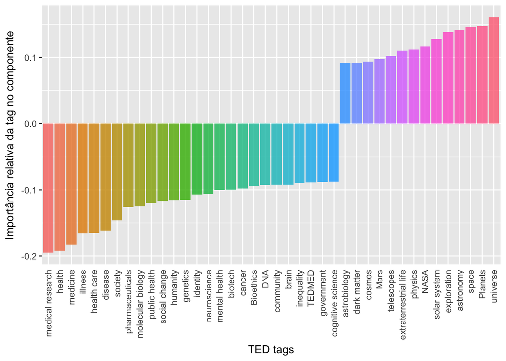

```r
tidied_pca %>%
  filter(PC == "PC2") %>%
  top_n(40, abs(Contribution)) %>%
  mutate(tag = reorder(tag, Contribution)) %>%
  ggplot(aes(tag, Contribution, fill = tag)) +
  geom_col(show.legend = FALSE, alpha = 0.8) +
  theme(axis.text.x = element_text(angle = 90, hjust = 1, vjust = 0.5),
        axis.ticks.x = element_blank()) +
  labs(x = "TED tags",
       y = "Importância relativa da tag no componente")
```

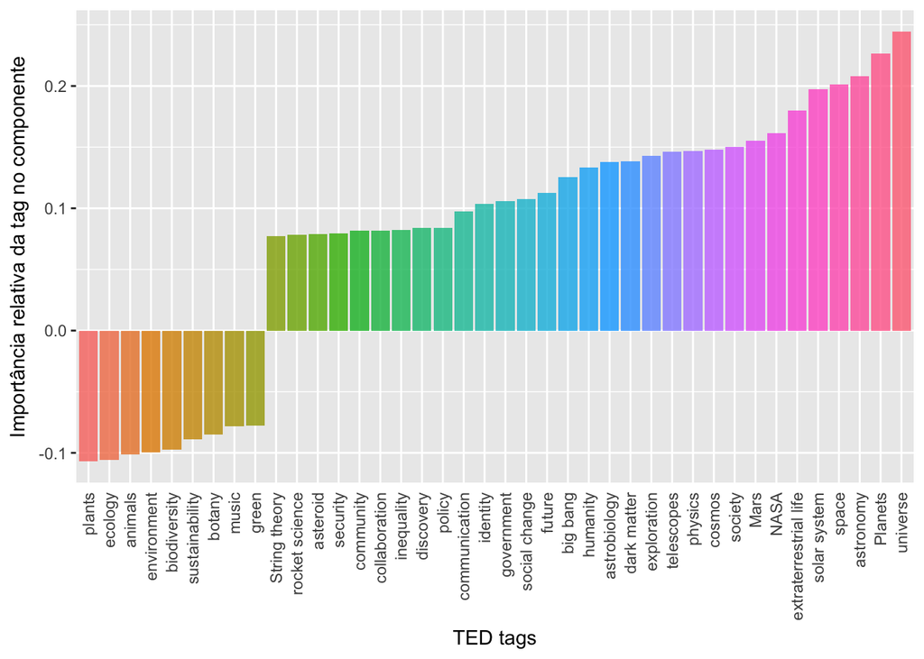

```r
tidied_pca %>%
  filter(PC == "PC4") %>%
  top_n(40, abs(Contribution)) %>%
  mutate(tag = reorder(tag, Contribution)) %>%
  ggplot(aes(tag, Contribution, fill = tag)) +
  geom_col(show.legend = FALSE, alpha = 0.8) +
  theme(axis.text.x = element_text(angle = 90, hjust = 1, vjust = 0.5),
        axis.ticks.x = element_blank()) +
  labs(x = "TED tags",
       y = "Importância relativa da tag no componente")
```

##### **Clustering** com as componentes principais

```r
talks_pcas <- tags_pca$x
rownames(talks_pcas) <- rownames(tags_scaled)

dissimilarity <- 1 - cor( t(talks_pcas), method = "pearson" ) # Transposição da matriz de tags para clusterização dos vídeos

distance <- as.dist( dissimilarity )
```

Utilizando o mesmo ponto de corte:

```r
hc <- hclust( distance )

agglom <- cutree(hc, h=0.40)
```

```r
ted_data %>%
  add_column( cluster_pca = agglom ) -> ted_data
```

Quais clusters criamos? Quantos vídeos por cluster?

```r
(clusters <- agglom %>% table() %>% sort(decreasing = TRUE))
```

```
## .
##   6  82  12  18  34 153  15   5  42  46  40  45 132 138  21 103  17  69
##  46  42  40  36  34  34  32  30  28  27  24  23  23  22  21  21  20  20
##  77 109 120 121 208 234  55 100 210 106 182  52 278 122 150  62 125 180
##  20  20  20  20  20  20  19  18  18  17  17  16  16  15  15  14  14  14
##  11  75  78  94  95 115 195 201 204  32  48  79 159 205 236 264 312  10
##  13  13  13  13  13  13  13  13  13  12  12  12  12  12  12  12  12  11
##  56  64  97 102 131 144 185  30  72 114 116 129 141 147 149 155 166 218
##  11  11  11  11  11  11  11  10  10  10  10  10  10  10  10  10  10  10
## 224 232 241 277 324   3   7  24  37  39  54  65  84 135 140 157 177 260
##  10  10  10  10  10   9   9   9   9   9   9   9   9   9   9   9   9   9
## 276 327  60  68  70  81  83 167 171 178 188 191 211 221 244 255 291 293
##   9   9   8   8   8   8   8   8   8   8   8   8   8   8   8   8   8   8
## 303 309   8   9  14  31  49  58  73  85 127 134 158 174 189 216 257  16
##   8   8   7   7   7   7   7   7   7   7   7   7   7   7   7   7   7   6
```

[output cut: 28 more lines]

```r
clusters_por_contagem <- clusters %>% names()

ted_data %>%
  filter( cluster_pca == clusters_por_contagem[1] )
```

| comments | description | duration | event | film_date | languages | main_speaker | name | num_speaker | published_date | ratings | related_talks | speaker_occupation | tags | title | url | views | cluster | cluster_pca |
| --- | --- | --- | --- | --- | --- | --- | --- | --- | --- | --- | --- | --- | --- | --- | --- | --- | --- | --- |
| 672 | Tony Robbins discusses the "invisible forces" that motivate everyone's actions -- and high-fives Al Gore in the front row. | 1305 | TED2006 | 1138838400 | 36 | Tony Robbins | Tony Robbins: Why we do what we do | 1 | 1151440680 | [{'id': 7, 'name': 'Funny', 'count': 1102}, {'id': 3, 'name': 'Courageous', 'count': 721}, {'id': 21, 'name': 'Unconvincing', 'count': 377}, {'id': 2, 'name': 'Confusing', 'count': 301}, {'id': 1, 'na… | [{'id': 229, 'hero': 'https://pe.tedcdn.com/images/ted/eefe30d20338d800bdc70a09dc0f6007e7355a74_2880x1620.jpg', 'speaker': 'Jill Bolte Taylor', 'title': 'My stroke of insight', 'duration': 1099, 'slug… | Life coach; expert in leadership psychology | ['business', 'culture', 'entertainment', 'goal-setting', 'motivation', 'potential', 'psychology'] | Why we do what we do | https://www.ted.com/talks/tony_robbins_asks_why_we_do_what_we_do\n | 20685401 | 6 | 6 |
| 919 | When two young Mormon missionaries knock on Julia Sweeney's door one day, it touches off a quest to completely rethink her own beliefs, in this excerpt from Sweeney's solo show "Letting Go of God." | 992 | TED2006 | 1140739200 | 31 | Julia Sweeney | Julia Sweeney: Letting go of God | 1 | 1152490260 | [{'id': 3, 'name': 'Courageous', 'count': 477}, {'id': 7, 'name': 'Funny', 'count': 2484}, {'id': 9, 'name': 'Ingenious', 'count': 320}, {'id': 21, 'name': 'Unconvincing', 'count': 225}, {'id': 1, 'na… | [{'id': 22, 'hero': 'https://pe.tedcdn.com/images/ted/f9e5462fd10b5130015fab95f3be6ace3e0f4ef4_1600x1200.jpg', 'speaker': 'Michael Shermer', 'title': 'Why people believe weird things', 'duration': 805… | Actor, comedian, playwright | ['Christianity', 'God', 'atheism', 'comedy', 'culture', 'humor', 'performance', 'religion', 'storytelling'] | Letting go of God | https://www.ted.com/talks/julia_sweeney_on_letting_go_of_god\n | 3769987 | 7 | 6 |
| 67 | Ashraf Ghani's passionate and powerful 10-minute talk, emphasizing the necessity of both economic investment and design ingenuity to rebuild broken states, is followed by a conversation with TED curat… | 1125 | TEDGlobal 2005 | 1121126400 | 24 | Ashraf Ghani | Ashraf Ghani: How to rebuild a broken state | 1 | 1161130260 | [{'id': 3, 'name': 'Courageous', 'count': 139}, {'id': 2, 'name': 'Confusing', 'count': 25}, {'id': 1, 'name': 'Beautiful', 'count': 48}, {'id': 9, 'name': 'Ingenious', 'count': 31}, {'id': 21, 'name'… | [{'id': 127, 'hero': 'https://pe.tedcdn.com/images/ted/5cd871dcf27ba4288021c2bfe6a3f6796dab2538_2880x1620.jpg', 'speaker': 'Ngozi Okonjo-Iweala', 'title': 'Want to help Africa? Do business here', 'dur… | President-elect of Afghanistan | ['business', 'corruption', 'culture', 'economics', 'entrepreneur', 'global development', 'global issues', 'investment', 'military', 'policy', 'politics', 'poverty'] | How to rebuild a broken state | https://www.ted.com/talks/ashraf_ghani_on_rebuilding_broken_states\n | 809226 | 6 | 6 |
| 276 | Poet Rives does 8 minutes of lyrical origami, folding history into a series of coincidences surrounding that most surreal of hours, 4 o'clock in the morning. | 552 | TED2007 | 1172880000 | 34 | Rives | Rives: The 4 a.m. mystery | 1 | 1184683440 | [{'id': 9, 'name': 'Ingenious', 'count': 891}, {'id': 7, 'name': 'Funny', 'count': 2460}, {'id': 3, 'name': 'Courageous', 'count': 43}, {'id': 1, 'name': 'Beautiful', 'count': 169}, {'id': 21, 'name':… | [{'id': 374, 'hero': 'https://pe.tedcdn.com/images/ted/078a7ecb2d3088979fc2e0e09a51572e372b28c7_2880x1620.jpg', 'speaker': 'John Hodgman', 'title': 'Aliens, love -- where are they?', 'duration': 1000,… | Performance poet, multimedia artist | ['entertainment', 'poetry', 'spoken word'] | The 4 a.m. mystery | https://www.ted.com/talks/rives_on_4_a_m\n | 3387765 | 120 | 6 |
| 151 | Is the beloved paper dictionary doomed to extinction? In this infectiously exuberant talk, leading lexicographer Erin McKean looks at the many ways today's print dictionary is poised for transformatio… | 950 | TED2007 | 1172880000 | 32 | Erin McKean | Erin McKean: The joy of lexicography | 1 | 1188459000 | [{'id': 3, 'name': 'Courageous', 'count': 45}, {'id': 10, 'name': 'Inspiring', 'count': 343}, {'id': 22, 'name': 'Fascinating', 'count': 518}, {'id': 1, 'name': 'Beautiful', 'count': 195}, {'id': 7, '… | [{'id': 69, 'hero': 'https://pe.tedcdn.com/images/ted/8bdfb6113efedf37e72cd88aa1dcf8103bcbf4e0_800x600.jpg', 'speaker': 'Wade Davis', 'title': 'Dreams from endangered cultures', 'duration': 1321, 'slu… | Dictionary editor | ['books', 'culture', 'education', 'entertainment', 'language'] | The joy of lexicography | https://www.ted.com/talks/erin_mckean_redefines_the_dictionary\n | 1013063 | 6 | 6 |
| 258 | Building sophisticated educational tools out of cheap parts, Johnny Lee demos his cool Wii Remote hacks, which turn the $40 video game controller into a digital whiteboard, a touchscreen and a head-mo… | 340 | TED2008 | 1204156800 | 36 | Johnny Lee | Johnny Lee: Free or cheap Wii Remote hacks | 1 | 1207872300 | [{'id': 8, 'name': 'Informative', 'count': 843}, {'id': 22, 'name': 'Fascinating', 'count': 1684}, {'id': 10, 'name': 'Inspiring', 'count': 1338}, {'id': 9, 'name': 'Ingenious', 'count': 3249}, {'id':… | [{'id': 129, 'hero': 'https://pe.tedcdn.com/images/ted/5824aa5b8d490ed3863ee1f8c26731a6ebbfcefe_1600x1200.jpg', 'speaker': 'Blaise Agüera y Arcas', 'title': "How PhotoSynth can connect the world's ima… | Human-computer interaction researcher | ['business', 'demo', 'design', 'education', 'entertainment', 'gaming', 'hack', 'technology'] | Free or cheap Wii Remote hacks | https://www.ted.com/talks/johnny_lee_demos_wii_remote_hacks\n | 5483940 | 205 | 6 |
| 43 | Torsten Reil talks about how the study of biology can help make natural-looking animated people -- by building a human from the inside out, with bones, muscles and a nervous system. He spoke at TED in… | 1100 | TED2003 | 1046649600 | 19 | Torsten Reil | Torsten Reil: Animate characters by evolving them | 1 | 1215478800 | [{'id': 21, 'name': 'Unconvincing', 'count': 11}, {'id': 11, 'name': 'Longwinded', 'count': 18}, {'id': 1, 'name': 'Beautiful', 'count': 14}, {'id': 9, 'name': 'Ingenious', 'count': 150}, {'id': 23, '… | [{'id': 280, 'hero': 'https://pe.tedcdn.com/images/ted/8797510dd2c00e81d277493d9ca173f6ea5de0ec_2880x1620.jpg', 'speaker': 'Robert Full', 'title': 'Robots inspired by cockroach ingenuity', 'duration':… | Animating neurobiologist | ['animals', 'animation', 'biomechanics', 'demo', 'design', 'entertainment', 'gaming', 'technology', 'virtual reality'] | Animate characters by evolving them | https://www.ted.com/talks/torsten_reil_studies_biology_to_make_animation\n | 325148 | 239 | 6 |
| 36 | Reed Kroloff gives us a new lens for judging new architecture: is it modern, or is it romantic? Look for glorious images from two leading practices -- and a blistering critique of the 9/11 planning pr… | 921 | TED2003 | 1044144000 | 18 | Reed Kroloff | Reed Kroloff: A tour of modern architecture | 1 | 1217226960 | [{'id': 1, 'name': 'Beautiful', 'count': 48}, {'id': 8, 'name': 'Informative', 'count': 71}, {'id': 9, 'name': 'Ingenious', 'count': 18}, {'id': 7, 'name': 'Funny', 'count': 33}, {'id': 2, 'name': 'Co… | [{'id': 49, 'hero': 'https://pe.tedcdn.com/images/ted/9f9878bdcc3b7c86ae7dda75e7b6dfb2eb5dd78e_2880x1620.jpg', 'speaker': 'Joshua Prince-Ramus', 'title': "Behind the design of Seattle's library", 'dur… | Architecture critic | ['architecture', 'art', 'business', 'design', 'humor'] | A tour of modern architecture | https://www.ted.com/talks/reed_kroloff_on_modern_and_romantic_architecture\n | 282994 | 205 | 6 |
| 68 | Storyteller Carmen Agra Deedy spins a funny, wise and luminous tale of parents and kids, starring her Cuban mother. Settle in and enjoy the ride -- Mama's driving! | 1414 | TED2005 | 1107302400 | 23 | Carmen Agra Deedy | Carmen Agra Deedy: Once upon a time, my mother ... | 1 | 1221181200 | [{'id': 25, 'name': 'OK', 'count': 84}, {'id': 7, 'name': 'Funny', 'count': 481}, {'id': 23, 'name': 'Jaw-dropping', 'count': 35}, {'id': 2, 'name': 'Confusing', 'count': 24}, {'id': 21, 'name': 'Unco… | [{'id': 60, 'hero': 'https://pe.tedcdn.com/images/ted/b538bc5fb569cc2a617db5ddc1e42935bceb00c6_2880x1620.jpg', 'speaker': 'Anna Deavere Smith', 'title': 'Four American characters', 'duration': 1385, '… | Storyteller | ['children', 'entertainment', 'memory', 'storytelling'] | Once upon a time, my mother ... | https://www.ted.com/talks/carmen_agra_deedy_spins_stories\n | 672797 | 7 | 6 |
| 36 | Zambia-born filmmaker Franco Sacchi tours us through Nollywood, Nigeria's booming film industry (the world's 3rd largest). Guerrilla filmmaking and brilliance under pressure from crews that can shoot … | 1054 | TEDGlobal 2007 | 1181088000 | 19 | Franco Sacchi | Franco Sacchi: A tour of Nollywood, Nigeria's booming film industry | 1 | 1227056400 | [{'id': 25, 'name': 'OK', 'count': 28}, {'id': 8, 'name': 'Informative', 'count': 86}, {'id': 10, 'name': 'Inspiring', 'count': 95}, {'id': 22, 'name': 'Fascinating', 'count': 48}, {'id': 23, 'name': … | [{'id': 205, 'hero': 'https://pe.tedcdn.com/images/ted/d1336ca1c021209da3838b06360e6b8db33a7b84_2880x1620.jpg', 'speaker': 'J.J. Abrams', 'title': 'The mystery box', 'duration': 1082, 'slug': 'j_j_abr… | Filmmaker | ['Africa', 'creativity', 'culture', 'entertainment', 'film', 'global issues', 'media', 'movies', 'technology'] | A tour of Nollywood, Nigeria's booming film industry | https://www.ted.com/talks/franco_sacchi_on_nollywood\n | 223082 | 311 | 6 |

[output cut: 36 more lines]

```r
ted_data %>%
  filter( cluster_pca == clusters_por_contagem[2] )
```

| comments | description | duration | event | film_date | languages | main_speaker | name | num_speaker | published_date | ratings | related_talks | speaker_occupation | tags | title | url | views | cluster | cluster_pca |
| --- | --- | --- | --- | --- | --- | --- | --- | --- | --- | --- | --- | --- | --- | --- | --- | --- | --- | --- |
| 67 | Violinist Natalie MacMaster and TED Musical Director Thomas Dolby play Dolby's original song "Blue Is a River" in this ethereal duet -- with a little dancing. | 311 | TED2002 | 1012608000 | 30 | Natalie MacMaster | Natalie MacMaster: Cape Breton fiddling in reel time | 2 | 1178040660 | [{'id': 1, 'name': 'Beautiful', 'count': 364}, {'id': 11, 'name': 'Longwinded', 'count': 29}, {'id': 21, 'name': 'Unconvincing', 'count': 22}, {'id': 10, 'name': 'Inspiring', 'count': 102}, {'id': 7, … | [{'id': 45, 'hero': 'https://pe.tedcdn.com/images/ted/c9d557daca38221e5929b15793999987c470e1e2_2880x1620.jpg', 'speaker': 'Sirena Huang', 'title': "An 11-year-old's magical violin", 'duration': 1481, … | Fiddler | ['entertainment', 'history', 'live music', 'music', 'performance', 'violin'] | Cape Breton fiddling in reel time | https://www.ted.com/talks/natalie_macmaster_fiddles_in_reel_time\n | 717002 | 98 | 82 |
| 279 | Environmental scientist David Keith proposes a cheap, effective, shocking means to address climate change: What if we injected a huge cloud of ash into the atmosphere to deflect sunlight and heat? | 958 | TEDSalon 2007 Hot Science | 1189296000 | 24 | David Keith | David Keith: A critical look at geoengineering against climate change | 1 | 1194918240 | [{'id': 8, 'name': 'Informative', 'count': 680}, {'id': 3, 'name': 'Courageous', 'count': 262}, {'id': 10, 'name': 'Inspiring', 'count': 166}, {'id': 22, 'name': 'Fascinating', 'count': 300}, {'id': 9… | [{'id': 193, 'hero': 'https://pe.tedcdn.com/images/ted/20429_480x360.jpg', 'speaker': 'Juan Enriquez', 'title': 'Using biology to rethink the energy challenge', 'duration': 1090, 'slug': 'juan_enrique… | Environmental scientist | ['business', 'china', 'climate change', 'engineering', 'global issues', 'science', 'technology'] | A critical look at geoengineering against climate change | https://www.ted.com/talks/david_keith_s_surprising_ideas_on_climate_change\n | 876658 | 155 | 82 |
| 144 | Woody Norris shows off two of his inventions that use sound in new ways, including the Long Range Acoustic Device, or LRAD. He talks about his untraditional approach to inventing and education, becaus… | 829 | TED2004 | 1075680000 | 22 | Woody Norris | Woody Norris: Hypersonic sound and other inventions | 1 | 1232931600 | [{'id': 9, 'name': 'Ingenious', 'count': 756}, {'id': 10, 'name': 'Inspiring', 'count': 180}, {'id': 8, 'name': 'Informative', 'count': 185}, {'id': 22, 'name': 'Fascinating', 'count': 401}, {'id': 25… | [{'id': 492, 'hero': 'https://pe.tedcdn.com/images/ted/79015_800x600.jpg', 'speaker': 'Saul Griffith', 'title': 'High-altitude wind energy from kites!', 'duration': 325, 'slug': 'saul_griffith_on_kite… | Inventor | ['business', 'creativity', 'design', 'invention', 'technology'] | Hypersonic sound and other inventions | https://www.ted.com/talks/woody_norris_invents_amazing_things\n | 1205867 | 338 | 82 |
| 70 | Cynthia Schneider looks at two international "American Idol"-style shows -- one in Afghanistan, and one in the United Arab Emirates -- and shows the surprising effect that these reality-TV competition… | 337 | TEDGlobal 2009 | 1246924800 | 29 | Cynthia Schneider | Cynthia Schneider: The surprising spread of Idol TV | 1 | 1258074000 | [{'id': 2, 'name': 'Confusing', 'count': 13}, {'id': 21, 'name': 'Unconvincing', 'count': 28}, {'id': 8, 'name': 'Informative', 'count': 252}, {'id': 22, 'name': 'Fascinating', 'count': 143}, {'id': 1… | [{'id': 689, 'hero': 'https://pe.tedcdn.com/images/ted/133260_800x600.jpg', 'speaker': 'Shashi Tharoor', 'title': 'Why nations should pursue soft power', 'duration': 1073, 'slug': 'shashi_tharoor', 'v… | Cultural diplomacy expert | ['culture', 'entertainment', 'global issues', 'poetry', 'politics'] | The surprising spread of Idol TV | https://www.ted.com/talks/cynthia_schneider_the_surprising_spread_of_idol_tv\n | 441609 | 473 | 82 |
| 97 | Loretta Napoleoni details her rare opportunity to talk to the secretive Italian Red Brigades -- an experience that sparked a lifelong interest in terrorism. She gives a behind-the-scenes look at its c… | 944 | TEDGlobal 2009 | 1247616000 | 28 | Loretta Napoleoni | Loretta Napoleoni: The intricate economics of terrorism | 1 | 1260773160 | [{'id': 24, 'name': 'Persuasive', 'count': 165}, {'id': 8, 'name': 'Informative', 'count': 477}, {'id': 10, 'name': 'Inspiring', 'count': 71}, {'id': 22, 'name': 'Fascinating', 'count': 317}, {'id': 3… | [{'id': 665, 'hero': 'https://pe.tedcdn.com/images/ted/125000_800x600.jpg', 'speaker': 'Ian Goldin', 'title': 'Navigating our global future', 'duration': 426, 'slug': 'ian_goldin_navigating_our_global… | Macroeconomist | ['corruption', 'economics', 'global issues', 'money', 'terrorism'] | The intricate economics of terrorism | https://www.ted.com/talks/loretta_napoleoni_the_intricate_economics_of_terrorism\n | 639995 | 488 | 82 |
| 650 | We all know the arguments that being vegetarian is better for the environment and for the animals -- but in a carnivorous culture, it can be hard to make the change. Graham Hill has a powerful, pragma… | 345 | TED2010 | 1265760000 | 49 | Graham Hill | Graham Hill: Why I'm a weekday vegetarian | 1 | 1274168700 | [{'id': 25, 'name': 'OK', 'count': 438}, {'id': 24, 'name': 'Persuasive', 'count': 975}, {'id': 9, 'name': 'Ingenious', 'count': 242}, {'id': 10, 'name': 'Inspiring', 'count': 780}, {'id': 21, 'name':… | [{'id': 537, 'hero': 'https://pe.tedcdn.com/images/ted/f217ab8a2ad9736df7833243e673be93c816bf4d_2880x1620.jpg', 'speaker': 'Louise Fresco', 'title': 'We need to feed the whole world', 'duration': 1080… | Journalist | ['culture', 'food', 'global issues', 'green'] | Why I'm a weekday vegetarian | https://www.ted.com/talks/graham_hill_weekday_vegetarian\n | 2108816 | 569 | 82 |
| 68 | Think of penguins as ocean sentinels, says Dee Boersma -- they're on the frontlines of sea change. Sharing stories of penguin life and culture, she suggests that we start listening to what penguins ar… | 909 | Mission Blue Voyage | 1270857600 | 21 | Dee Boersma | Dee Boersma: Pay attention to penguins | 1 | 1274258760 | [{'id': 22, 'name': 'Fascinating', 'count': 73}, {'id': 8, 'name': 'Informative', 'count': 125}, {'id': 21, 'name': 'Unconvincing', 'count': 12}, {'id': 11, 'name': 'Longwinded', 'count': 16}, {'id': … | [{'id': 830, 'hero': 'https://pe.tedcdn.com/images/ted/163962_800x600.jpg', 'speaker': 'Mike deGruy', 'title': 'Hooked by an octopus', 'duration': 1092, 'slug': 'mike_degruy_hooked_by_octopus', 'viewe… | Conservation biologist | ['animals', 'global issues', 'mission blue', 'oceans', 'science'] | Pay attention to penguins | https://www.ted.com/talks/dee_boersma_pay_attention_to_penguins\n | 358820 | 569 | 82 |
| 396 | Statistician Nic Marks asks why we measure a nation's success by its productivity -- instead of by the happiness and well-being of its people. He introduces the Happy Planet Index, which tracks nation… | 1009 | TEDGlobal 2010 | 1279238400 | 36 | Nic Marks | Nic Marks: The Happy Planet Index | 1 | 1283130000 | [{'id': 3, 'name': 'Courageous', 'count': 218}, {'id': 22, 'name': 'Fascinating', 'count': 316}, {'id': 1, 'name': 'Beautiful', 'count': 241}, {'id': 24, 'name': 'Persuasive', 'count': 592}, {'id': 10… | [{'id': 97, 'hero': 'https://pe.tedcdn.com/images/ted/016a827cc0757092a0439ab2a63feca8655b6c29_1600x1200.jpg', 'speaker': 'Dan Gilbert', 'title': 'The surprising science of happiness', 'duration': 127… | Happiness researcher | ['big problems', 'culture', 'data', 'economics', 'global issues', 'happiness', 'statistics'] | The Happy Planet Index | https://www.ted.com/talks/nic_marks_the_happy_planet_index\n | 1597719 | 473 | 82 |
| 568 | Human growth has strained the Earth's resources, but as Johan Rockstrom reminds us, our advances also give us the science to recognize this and change behavior. His research has found nine "planetary … | 1090 | TEDGlobal 2010 | 1279238400 | 25 | Johan Rockstrom | Johan Rockstrom: Let the environment guide our development | 1 | 1283244120 | [{'id': 25, 'name': 'OK', 'count': 106}, {'id': 8, 'name': 'Informative', 'count': 406}, {'id': 2, 'name': 'Confusing', 'count': 23}, {'id': 21, 'name': 'Unconvincing', 'count': 36}, {'id': 24, 'name'… | [{'id': 535, 'hero': 'https://pe.tedcdn.com/images/ted/f1662e3d637698958d7aa87d6f4cf9031c0c9d0b_1600x1200.jpg', 'speaker': 'Al Gore', 'title': 'What comes after An Inconvenient Truth?', 'duration': 46… | Sustainability expert | ['Anthropocene', 'agriculture', 'cities', 'climate change', 'environment', 'global issues'] | Let the environment guide our development | https://www.ted.com/talks/johan_rockstrom_let_the_environment_guide_our_development\n | 924806 | 473 | 82 |
| 364 | As the world faces recession, climate change, inequity and more, Tim Jackson delivers a piercing challenge to established economic principles, explaining how we might stop feeding the crises and start… | 1223 | TEDGlobal 2010 | 1279152000 | 28 | Tim Jackson | Tim Jackson: An economic reality check | 1 | 1286270340 | [{'id': 26, 'name': 'Obnoxious', 'count': 32}, {'id': 10, 'name': 'Inspiring', 'count': 631}, {'id': 3, 'name': 'Courageous', 'count': 191}, {'id': 24, 'name': 'Persuasive', 'count': 440}, {'id': 22, … | [{'id': 62, 'hero': 'https://pe.tedcdn.com/images/ted/173_480x360.jpg', 'speaker': 'Bjorn Lomborg', 'title': 'Global priorities bigger than climate change', 'duration': 1001, 'slug': 'bjorn_lomborg_se… | Economist | ['economics', 'global development', 'green', 'poverty', 'sustainability'] | An economic reality check | https://www.ted.com/talks/tim_jackson_s_economic_reality_check\n | 899942 | 338 | 82 |

[output cut: 32 more lines]

```r
ted_data %>%
  filter( cluster_pca == clusters_por_contagem[3] )
```

| comments | description | duration | event | film_date | languages | main_speaker | name | num_speaker | published_date | ratings | related_talks | speaker_occupation | tags | title | url | views | cluster | cluster_pca |
| --- | --- | --- | --- | --- | --- | --- | --- | --- | --- | --- | --- | --- | --- | --- | --- | --- | --- | --- |
| 71 | Accepting the 2006 TED Prize, Dr. Larry Brilliant talks about how smallpox was eradicated from the planet, and calls for a new global system that can identify and contain pandemics before they spread. | 1550 | TED2006 | 1140652800 | 24 | Larry Brilliant | Larry Brilliant: My wish: Help me stop pandemics | 1 | 1153786260 | [{'id': 8, 'name': 'Informative', 'count': 188}, {'id': 3, 'name': 'Courageous', 'count': 86}, {'id': 11, 'name': 'Longwinded', 'count': 9}, {'id': 1, 'name': 'Beautiful', 'count': 16}, {'id': 10, 'na… | [{'id': 1153, 'hero': 'https://pe.tedcdn.com/images/ted/55e8224d694fec895e6f95aa6fad6ee7fe091bb7_800x600.jpg', 'speaker': 'Bruce Aylward', 'title': "How we'll stop polio for good", 'duration': 1389, '… | Epidemiologist, philanthropist | ['TED Prize', 'collaboration', 'disease', 'ebola', 'global issues', 'health', 'science', 'technology'] | My wish: Help me stop pandemics | https://www.ted.com/talks/larry_brilliant_wants_to_stop_pandemics\n | 693341 | 13 | 12 |
| 39 | A happy song about global warming, from Jill Sobule. | 163 | TED2006 | 1140912000 | 38 | Jill Sobule | Jill Sobule: Global warming's theme song, "Manhattan in January" | 1 | 1175819400 | [{'id': 9, 'name': 'Ingenious', 'count': 45}, {'id': 7, 'name': 'Funny', 'count': 259}, {'id': 1, 'name': 'Beautiful', 'count': 84}, {'id': 8, 'name': 'Informative', 'count': 11}, {'id': 21, 'name': '… | [{'id': 222, 'hero': 'https://pe.tedcdn.com/images/ted/31348_480x360.jpg', 'speaker': 'Jill Sobule + Julia Sweeney', 'title': 'The Jill and Julia Show', 'duration': 374, 'slug': 'the_jill_and_julia_sh… | Singer/songwriter | ['climate change', 'environment', 'guitar', 'music', 'performance', 'vocals'] | Global warming's theme song, "Manhattan in January" | https://www.ted.com/talks/jill_sobule_sings_to_al_gore\n | 591379 | 86 | 12 |
| 588 | In the days following the tragic South Asian tsunami of 2004, the Rev. Tom Honey pondered the question, "How could a loving God have done this?" Here is his answer. | 1172 | TED2005 | 1107302400 | 22 | Tom Honey | Tom Honey: Why would God create a tsunami? | 1 | 1176688500 | [{'id': 3, 'name': 'Courageous', 'count': 435}, {'id': 11, 'name': 'Longwinded', 'count': 104}, {'id': 2, 'name': 'Confusing', 'count': 87}, {'id': 1, 'name': 'Beautiful', 'count': 223}, {'id': 21, 'n… | [{'id': 234, 'hero': 'https://pe.tedcdn.com/images/ted/e653c223738e3bb9496a323298be3d6b7f72aa32_2880x1620.jpg', 'speaker': 'Karen Armstrong', 'title': 'My wish: The Charter for Compassion', 'duration'… | Priest | ['God', 'culture', 'disaster relief', 'global issues', 'natural disaster', 'philosophy', 'religion'] | Why would God create a tsunami? | https://www.ted.com/talks/tom_honey_on_god_and_the_tsunami\n | 616385 | 94 | 12 |
| 101 | Kenichi Ebina moves his body in a manner that appears to defy the limits imposed by the human skeleton. He combines breakdancing and hip-hop with mime using movements that are simultaneously precise a… | 212 | TED2007 | 1172880000 | 43 | Kenichi Ebina | Kenichi Ebina: My magic moves | 1 | 1191403500 | [{'id': 7, 'name': 'Funny', 'count': 307}, {'id': 1, 'name': 'Beautiful', 'count': 414}, {'id': 21, 'name': 'Unconvincing', 'count': 200}, {'id': 22, 'name': 'Fascinating', 'count': 562}, {'id': 9, 'n… | [{'id': 24, 'hero': 'https://pe.tedcdn.com/images/ted/22_480x360.jpg', 'speaker': 'Pilobolus', 'title': 'A dance of "Symbiosis"', 'duration': 825, 'slug': 'pilobolus_perform_symbiosis', 'viewed_count'… | Dancer | ['culture', 'dance', 'entertainment', 'performance'] | My magic moves | https://www.ted.com/talks/kenichi_ebina_s_magic_moves\n | 1720579 | 144 | 12 |
| 53 | Author George Dyson spins the story of Project Orion, a massive, nuclear-powered spacecraft that could have taken us to Saturn in five years. His insider’s perspective and a secret cache of documents … | 518 | TED2002 | 1012608000 | 24 | George Dyson | George Dyson: The story of Project Orion | 1 | 1202966580 | [{'id': 23, 'name': 'Jaw-dropping', 'count': 79}, {'id': 22, 'name': 'Fascinating', 'count': 206}, {'id': 9, 'name': 'Ingenious', 'count': 36}, {'id': 8, 'name': 'Informative', 'count': 196}, {'id': 7… | [{'id': 4, 'hero': 'https://pe.tedcdn.com/images/ted/1b5cb72c2fa3e58e4c268e9e37eba833b43689bb_1600x1200.jpg', 'speaker': 'Burt Rutan', 'title': 'The real future of space exploration', 'duration': 1177… | Historian of science | ['NASA', 'Planets', 'future', 'history', 'physics', 'rocket science', 'science', 'space', 'storytelling', 'technology'] | The story of Project Orion | https://www.ted.com/talks/george_dyson_on_project_orion\n | 785872 | 184 | 12 |
| 83 | Insects and animals have evolved some amazing skills -- but, as Robert Full notes, many animals are actually over-engineered. The trick is to copy only what's necessary. He shows how human engineers c… | 1222 | TED2002 | 1012608000 | 19 | Robert Full | Robert Full: Robots inspired by cockroach ingenuity | 1 | 1213837500 | [{'id': 10, 'name': 'Inspiring', 'count': 221}, {'id': 8, 'name': 'Informative', 'count': 255}, {'id': 22, 'name': 'Fascinating', 'count': 495}, {'id': 9, 'name': 'Ingenious', 'count': 276}, {'id': 1,… | [{'id': 82, 'hero': 'https://pe.tedcdn.com/images/ted/15238_480x360.jpg', 'speaker': 'Dean Kamen', 'title': 'Luke, a new prosthetic arm for soldiers', 'duration': 310, 'slug': 'dean_kamen_previews_a_n… | Biologist | ['animals', 'design', 'evolution', 'robots', 'science', 'technology', 'transportation'] | Robots inspired by cockroach ingenuity | https://www.ted.com/talks/robert_full_on_engineering_and_evolution\n | 799797 | 228 | 12 |
| 638 | Benjamin Zander has two infectious passions: classical music, and helping us all realize our untapped love for it -- and by extension, our untapped love for all new possibilities, new experiences, new… | 1243 | TED2008 | 1201910400 | 45 | Benjamin Zander | Benjamin Zander: The transformative power of classical music | 1 | 1214355600 | [{'id': 1, 'name': 'Beautiful', 'count': 5967}, {'id': 7, 'name': 'Funny', 'count': 1960}, {'id': 10, 'name': 'Inspiring', 'count': 8108}, {'id': 22, 'name': 'Fascinating', 'count': 2736}, {'id': 8, '… | [{'id': 103, 'hero': 'https://pe.tedcdn.com/images/ted/1d7e013f1870ec08fce3c48348881a9eac074ab6_1600x1200.jpg', 'speaker': 'Evelyn Glennie', 'title': 'How to truly listen', 'duration': 1929, 'slug': '… | Conductor | ['conducting', 'creativity', 'culture', 'entertainment', 'live music', 'music', 'performance'] | The transformative power of classical music | https://www.ted.com/talks/benjamin_zander_on_music_and_passion\n | 9315483 | 231 | 12 |
| 166 | Nine days before TED2008, filmmaker David Hoffman lost almost everything he owned in a fire that destroyed his home, office and 30 years of passionate collecting. He looks back at a life that's been w… | 240 | TED2008 | 1201910400 | 38 | David Hoffman | David Hoffman: What happens when you lose everything | 1 | 1215565200 | [{'id': 8, 'name': 'Informative', 'count': 36}, {'id': 1, 'name': 'Beautiful', 'count': 65}, {'id': 10, 'name': 'Inspiring', 'count': 250}, {'id': 3, 'name': 'Courageous', 'count': 224}, {'id': 26, 'n… | [{'id': 73, 'hero': 'https://pe.tedcdn.com/images/ted/1c4414e5e8c5dbb93483ea5d718cf05957f3d3f7_2880x1620.jpg', 'speaker': 'Carl Honoré', 'title': 'In praise of slowness', 'duration': 1155, 'slug': 'ca… | Filmmaker | ['culture', 'film', 'library', 'movies', 'personal growth', 'storytelling'] | What happens when you lose everything | https://www.ted.com/talks/david_hoffman_on_losing_everything\n | 920941 | 161 | 12 |
| 30 | Join Rev. James Forbes at the dinner table of his Southern childhood, where his mother and father taught him what compassion really means day to day -- sharing with those who need love. | 1118 | Chautauqua Institution | 1254355200 | 20 | James Forbes | James Forbes: Compassion at the dinner table | 1 | 1225428300 | [{'id': 10, 'name': 'Inspiring', 'count': 73}, {'id': 1, 'name': 'Beautiful', 'count': 47}, {'id': 8, 'name': 'Informative', 'count': 12}, {'id': 7, 'name': 'Funny', 'count': 6}, {'id': 26, 'name': 'O… | [{'id': 674, 'hero': 'https://pe.tedcdn.com/images/ted/127310_800x600.jpg', 'speaker': 'Dayananda Saraswati', 'title': 'The profound journey of compassion', 'duration': 1014, 'slug': 'swami_dayananda_… | Preacher | ['charter for compassion', 'compassion', 'faith', 'global issues', 'life', 'religion'] | Compassion at the dinner table | https://www.ted.com/talks/james_forbes\n | 204410 | 299 | 12 |
| 389 | Forget about the hybrid auto -- Shai Agassi says it's electric cars or bust if we want to impact emissions. His company, Better Place, has a radical plan to take entire countries oil-free by 2020. | 1086 | TED2009 | 1233792000 | 25 | Shai Agassi | Shai Agassi: A new ecosystem for electric cars | 1 | 1239584400 | [{'id': 21, 'name': 'Unconvincing', 'count': 82}, {'id': 23, 'name': 'Jaw-dropping', 'count': 315}, {'id': 10, 'name': 'Inspiring', 'count': 868}, {'id': 24, 'name': 'Persuasive', 'count': 869}, {'id'… | [{'id': 492, 'hero': 'https://pe.tedcdn.com/images/ted/79015_800x600.jpg', 'speaker': 'Saul Griffith', 'title': 'High-altitude wind energy from kites!', 'duration': 325, 'slug': 'saul_griffith_on_kite… | Green auto pioneer | ['alternative energy', 'business', 'cars', 'energy', 'global issues', 'green', 'infrastructure', 'technology'] | A new ecosystem for electric cars | https://www.ted.com/talks/shai_agassi_on_electric_cars\n | 1139068 | 381 | 12 |

[output cut: 30 more lines]